# Import Data

```python
# Import libraries
import pandas as pd
import matplotlib.pyplot as plt
import seaborn as sns
```

```python
# Data Overview

dataset = pd.read_csv('C:/Users/syedr/OneDrive/Documents/DAB Subjects/Sem-3/MarketAnalytics/Project-4/customer_lifetime_value_dataset.csv')
dataset.head()
```

|  | customerid | firstpurchasedate | lastpurchasedate | totalpurchases | totalrevenue | referralsource | churnindicator | discountsused | productcategory | responsetolastcampaign | feedbackscore | preferredpaymentmethod | supportticketsraised | hasloyaltycard | frequency |
| --- | --- | --- | --- | --- | --- | --- | --- | --- | --- | --- | --- | --- | --- | --- | --- |
| 0 | 8519 | 2021-12-31 | 2022-03-06 | 7 | 11670 | Online advertisements | 0 | 2 | Q02 | ignored | 4.729998 | debit card | 0 | no | 7 |
| 1 | 38152 | 2019-09-27 | 2023-02-02 | 20 | 5260 | Traditional media outreach | 1 | 6 | F76 | purchased | 4.184512 | cash | 0 | no | 2 |
| 2 | 19680 | 2021-06-13 | 2022-02-04 | 29 | 9790 | Influencer endorsements | 0 | 2 | X04 | opened mail | 4.346640 | google pay | 0 | no | 4 |
| 3 | 35744 | 2021-07-28 | 2022-08-21 | 15 | 9591 | Influencer endorsements | 0 | 5 | A25 | ignored | 5.000000 | debit card | 0 | no | 13 |
| 4 | 11663 | 2021-01-19 | 2022-03-10 | 13 | 10134 | Word of mouth | 0 | 3 | A16 | ignored | 4.482089 | credit card | 0 | no | 11 |

```python
dataset.describe
```

```
<bound method NDFrame.describe of       customerid firstpurchasedate lastpurchasedate  totalpurchases  \
0           8519        2021-12-31       2022-03-06               7
1          38152        2019-09-27       2023-02-02              20
2          19680        2021-06-13       2022-02-04              29
3          35744        2021-07-28       2022-08-21              15
4          11663        2021-01-19       2022-03-10              13
...          ...               ...              ...             ...
9995       21419        2020-07-15       2023-07-18              13
9996       24140        2019-05-24       2021-07-05              13
9997       32519        2021-04-21       2021-05-26              17
9998       47248        2021-04-15       2021-08-15              27
9999       44996        2020-02-22       2023-04-11               7

      totalrevenue              referralsource  churnindicator  discountsused  \
0            11670       Online advertisements               0              2
```

[output cut: 38 more lines]

```python
dataset.dtypes
```

```
customerid                  int64
firstpurchasedate          object
lastpurchasedate           object
totalpurchases              int64
totalrevenue                int64
referralsource             object
churnindicator              int64
discountsused               int64
productcategory            object
responsetolastcampaign     object
feedbackscore             float64
preferredpaymentmethod     object
supportticketsraised       object
hasloyaltycard             object
frequency                   int64
dtype: object
```

```python
# Converting the date columns to datetime format for calculations
dataset['firstpurchasedate'] = pd.to_datetime(dataset['firstpurchasedate'])
dataset['lastpurchasedate'] = pd.to_datetime(dataset['lastpurchasedate'])
dataset.dtypes
```

```
customerid                         int64
firstpurchasedate         datetime64[ns]
lastpurchasedate          datetime64[ns]
totalpurchases                     int64
totalrevenue                       int64
referralsource                    object
churnindicator                     int64
discountsused                      int64
productcategory                   object
responsetolastcampaign            object
feedbackscore                    float64
preferredpaymentmethod            object
supportticketsraised              object
hasloyaltycard                    object
frequency                          int64
dtype: object
```

# Basic Feature Engineering:

1. Create 'avgpurchasevalue' Average value of purchases made by the customer (totalrevenue/totalpurchases).
2. Create 'recency' Number of days since the last purchase.
3. Create 'tenure' Number of days since the customer's first purchase (useful for understanding how long they've been a customer).
4. Create 'avgtimebetweenpurchases': Average number of days between purchases.

```python
# 1. Create 'avgpurchasevalue' Average value of purchases made by the customer (totalrevenue/totalpurchases).
dataset['avgpurchasevalue'] = dataset['totalrevenue'] / dataset['totalpurchases']
dataset.head(5)
```

|  | customerid | firstpurchasedate | lastpurchasedate | totalpurchases | totalrevenue | referralsource | churnindicator | discountsused | productcategory | responsetolastcampaign | feedbackscore | preferredpaymentmethod | supportticketsraised | hasloyaltycard | frequency | avgpurchasevalue |
| --- | --- | --- | --- | --- | --- | --- | --- | --- | --- | --- | --- | --- | --- | --- | --- | --- |
| 0 | 8519 | 2021-12-31 | 2022-03-06 | 7 | 11670 | Online advertisements | 0 | 2 | Q02 | ignored | 4.729998 | debit card | 0 | no | 7 | 1667.142857 |
| 1 | 38152 | 2019-09-27 | 2023-02-02 | 20 | 5260 | Traditional media outreach | 1 | 6 | F76 | purchased | 4.184512 | cash | 0 | no | 2 | 263.000000 |
| 2 | 19680 | 2021-06-13 | 2022-02-04 | 29 | 9790 | Influencer endorsements | 0 | 2 | X04 | opened mail | 4.346640 | google pay | 0 | no | 4 | 337.586207 |
| 3 | 35744 | 2021-07-28 | 2022-08-21 | 15 | 9591 | Influencer endorsements | 0 | 5 | A25 | ignored | 5.000000 | debit card | 0 | no | 13 | 639.400000 |
| 4 | 11663 | 2021-01-19 | 2022-03-10 | 13 | 10134 | Word of mouth | 0 | 3 | A16 | ignored | 4.482089 | credit card | 0 | no | 11 | 779.538462 |

```python
# 2. Create 'recency' Number of days since the last purchase.
#considering a constant date of '2023-09-01' to create the column.

constant_date = pd.to_datetime('2023-09-01')
dataset['recency'] = (constant_date - dataset['lastpurchasedate']).dt.days
dataset.head(5)
```

|  | customerid | firstpurchasedate | lastpurchasedate | totalpurchases | totalrevenue | referralsource | churnindicator | discountsused | productcategory | responsetolastcampaign | feedbackscore | preferredpaymentmethod | supportticketsraised | hasloyaltycard | frequency | avgpurchasevalue | recency |
| --- | --- | --- | --- | --- | --- | --- | --- | --- | --- | --- | --- | --- | --- | --- | --- | --- | --- |
| 0 | 8519 | 2021-12-31 | 2022-03-06 | 7 | 11670 | Online advertisements | 0 | 2 | Q02 | ignored | 4.729998 | debit card | 0 | no | 7 | 1667.142857 | 544 |
| 1 | 38152 | 2019-09-27 | 2023-02-02 | 20 | 5260 | Traditional media outreach | 1 | 6 | F76 | purchased | 4.184512 | cash | 0 | no | 2 | 263.000000 | 211 |
| 2 | 19680 | 2021-06-13 | 2022-02-04 | 29 | 9790 | Influencer endorsements | 0 | 2 | X04 | opened mail | 4.346640 | google pay | 0 | no | 4 | 337.586207 | 574 |
| 3 | 35744 | 2021-07-28 | 2022-08-21 | 15 | 9591 | Influencer endorsements | 0 | 5 | A25 | ignored | 5.000000 | debit card | 0 | no | 13 | 639.400000 | 376 |
| 4 | 11663 | 2021-01-19 | 2022-03-10 | 13 | 10134 | Word of mouth | 0 | 3 | A16 | ignored | 4.482089 | credit card | 0 | no | 11 | 779.538462 | 540 |

```python
# 3. Create 'tenure' Number of days since the customer's first purchase (useful for understanding how long they've been a customer).

# Set today_date as the latest date in the last purchase date column
today_date = dataset['lastpurchasedate'].max()

dataset['tenure'] = (today_date - dataset['firstpurchasedate']).dt.days
dataset.head(5)
```

|  | customerid | firstpurchasedate | lastpurchasedate | totalpurchases | totalrevenue | referralsource | churnindicator | discountsused | productcategory | responsetolastcampaign | feedbackscore | preferredpaymentmethod | supportticketsraised | hasloyaltycard | frequency | avgpurchasevalue | recency | tenure |
| --- | --- | --- | --- | --- | --- | --- | --- | --- | --- | --- | --- | --- | --- | --- | --- | --- | --- | --- |
| 0 | 8519 | 2021-12-31 | 2022-03-06 | 7 | 11670 | Online advertisements | 0 | 2 | Q02 | ignored | 4.729998 | debit card | 0 | no | 7 | 1667.142857 | 544 | 607 |
| 1 | 38152 | 2019-09-27 | 2023-02-02 | 20 | 5260 | Traditional media outreach | 1 | 6 | F76 | purchased | 4.184512 | cash | 0 | no | 2 | 263.000000 | 211 | 1433 |
| 2 | 19680 | 2021-06-13 | 2022-02-04 | 29 | 9790 | Influencer endorsements | 0 | 2 | X04 | opened mail | 4.346640 | google pay | 0 | no | 4 | 337.586207 | 574 | 808 |
| 3 | 35744 | 2021-07-28 | 2022-08-21 | 15 | 9591 | Influencer endorsements | 0 | 5 | A25 | ignored | 5.000000 | debit card | 0 | no | 13 | 639.400000 | 376 | 763 |
| 4 | 11663 | 2021-01-19 | 2022-03-10 | 13 | 10134 | Word of mouth | 0 | 3 | A16 | ignored | 4.482089 | credit card | 0 | no | 11 | 779.538462 | 540 | 953 |

```python
# 4. Create 'avgtimebetweenpurchases': Average number of days between purchases.

dataset['avgtimebetweenpurchases'] = dataset['tenure'] / dataset['totalpurchases']
dataset.head()
```

|  | customerid | firstpurchasedate | lastpurchasedate | totalpurchases | totalrevenue | referralsource | churnindicator | discountsused | productcategory | responsetolastcampaign | feedbackscore | preferredpaymentmethod | supportticketsraised | hasloyaltycard | frequency | avgpurchasevalue | recency | tenure | avgtimebetweenpurchases |
| --- | --- | --- | --- | --- | --- | --- | --- | --- | --- | --- | --- | --- | --- | --- | --- | --- | --- | --- | --- |
| 0 | 8519 | 2021-12-31 | 2022-03-06 | 7 | 11670 | Online advertisements | 0 | 2 | Q02 | ignored | 4.729998 | debit card | 0 | no | 7 | 1667.142857 | 544 | 607 | 86.714286 |
| 1 | 38152 | 2019-09-27 | 2023-02-02 | 20 | 5260 | Traditional media outreach | 1 | 6 | F76 | purchased | 4.184512 | cash | 0 | no | 2 | 263.000000 | 211 | 1433 | 71.650000 |
| 2 | 19680 | 2021-06-13 | 2022-02-04 | 29 | 9790 | Influencer endorsements | 0 | 2 | X04 | opened mail | 4.346640 | google pay | 0 | no | 4 | 337.586207 | 574 | 808 | 27.862069 |
| 3 | 35744 | 2021-07-28 | 2022-08-21 | 15 | 9591 | Influencer endorsements | 0 | 5 | A25 | ignored | 5.000000 | debit card | 0 | no | 13 | 639.400000 | 376 | 763 | 50.866667 |
| 4 | 11663 | 2021-01-19 | 2022-03-10 | 13 | 10134 | Word of mouth | 0 | 3 | A16 | ignored | 4.482089 | credit card | 0 | no | 11 | 779.538462 | 540 | 953 | 73.307692 |

# EDA

### Preliminary EDA:

```
1. Load the provided dataset into a Pandas DataFrame. Display the first 5 rows of the DataFrame to understand its structure.
2. Generate a report detailing the data types of each column in the dataset. How many of them are categorical? How many are numerical?
3. Compute and display basic statistical summaries (mean, median, standard deviation, etc.) for all the numerical columns in the dataset.
4. Identify any missing values in the dataset. How many missing values are there in each column?
```

```python
#1. Load the provided dataset into a Pandas DataFrame. Display the first 5 rows of the DataFrame to understand its structure.
print("First 5 Rows of the Dataset:")
dataset.head()
```

```
First 5 Rows of the Dataset:
```

|  | customerid | firstpurchasedate | lastpurchasedate | totalpurchases | totalrevenue | referralsource | churnindicator | discountsused | productcategory | responsetolastcampaign | feedbackscore | preferredpaymentmethod | supportticketsraised | hasloyaltycard | frequency | avgpurchasevalue | recency | tenure | avgtimebetweenpurchases |
| --- | --- | --- | --- | --- | --- | --- | --- | --- | --- | --- | --- | --- | --- | --- | --- | --- | --- | --- | --- |
| 0 | 8519 | 2021-12-31 | 2022-03-06 | 7 | 11670 | Online advertisements | 0 | 2 | Q02 | ignored | 4.729998 | debit card | 0 | no | 7 | 1667.142857 | 544 | 607 | 86.714286 |
| 1 | 38152 | 2019-09-27 | 2023-02-02 | 20 | 5260 | Traditional media outreach | 1 | 6 | F76 | purchased | 4.184512 | cash | 0 | no | 2 | 263.000000 | 211 | 1433 | 71.650000 |
| 2 | 19680 | 2021-06-13 | 2022-02-04 | 29 | 9790 | Influencer endorsements | 0 | 2 | X04 | opened mail | 4.346640 | google pay | 0 | no | 4 | 337.586207 | 574 | 808 | 27.862069 |
| 3 | 35744 | 2021-07-28 | 2022-08-21 | 15 | 9591 | Influencer endorsements | 0 | 5 | A25 | ignored | 5.000000 | debit card | 0 | no | 13 | 639.400000 | 376 | 763 | 50.866667 |
| 4 | 11663 | 2021-01-19 | 2022-03-10 | 13 | 10134 | Word of mouth | 0 | 3 | A16 | ignored | 4.482089 | credit card | 0 | no | 11 | 779.538462 | 540 | 953 | 73.307692 |

```python
# 2. Generate a report detailing the data types of each column in the dataset. How many of them are categorical? How many are numerical?

data_types = dataset.dtypes
categorical_columns = data_types[data_types == 'object'].index.tolist()
numerical_columns = data_types[data_types != 'object'].index.tolist()
num_categorical = len(categorical_columns)
num_numerical = len(numerical_columns)

print("\nData Types of Each Column:")
print(data_types)
print(f"\nNumber of Categorical Columns: {num_categorical}")
print(f"Number of Numerical Columns: {num_numerical}")
```

```
Data Types of Each Column:
customerid                          int64
firstpurchasedate          datetime64[ns]
lastpurchasedate           datetime64[ns]
totalpurchases                      int64
totalrevenue                        int64
referralsource                     object
churnindicator                      int64
discountsused                       int64
productcategory                    object
responsetolastcampaign             object
feedbackscore                     float64
preferredpaymentmethod             object
supportticketsraised               object
hasloyaltycard                     object
frequency                           int64
avgpurchasevalue                  float64
recency                             int64
tenure                              int64
avgtimebetweenpurchases           float64
dtype: object

Number of Categorical Columns: 6
Number of Numerical Columns: 13
```

```python
# 3. Compute and display basic statistical summaries (mean, median, standard deviation, etc.) for all the numerical columns in the dataset.
print("\nStatistical Summary for Numerical Columns:")
dataset.describe()
```

```
Statistical Summary for Numerical Columns:
```

|  | customerid | firstpurchasedate | lastpurchasedate | totalpurchases | totalrevenue | churnindicator | discountsused | feedbackscore | frequency | avgpurchasevalue | recency | tenure | avgtimebetweenpurchases |
| --- | --- | --- | --- | --- | --- | --- | --- | --- | --- | --- | --- | --- | --- |
| count | 10000.000000 | 10000 | 10000 | 10000.00000 | 10000.000000 | 10000.000000 | 10000.000000 | 10000.000000 | 10000.000000 | 10000.000000 | 10000.000000 | 10000.000000 | 10000.000000 |
| mean | 27519.237400 | 2020-08-20 10:49:00.480000 | 2022-02-24 23:18:23.040000 | 19.28050 | 8521.876100 | 0.498700 | 2.993600 | 4.433905 | 10.053700 | 629.636381 | 553.028900 | 1104.549300 | 78.617262 |
| min | 5000.000000 | 2019-02-04 00:00:00 | 2019-02-24 00:00:00 | 1.00000 | 4401.000000 | 0.000000 | 0.000000 | 1.006071 | 1.000000 | 123.150000 | 2.000000 | 5.000000 | 0.200000 |
| 25% | 16144.750000 | 2019-09-17 00:00:00 | 2021-05-27 00:00:00 | 13.00000 | 6427.750000 | 0.000000 | 1.000000 | 4.251318 | 4.000000 | 314.570238 | 222.000000 | 819.000000 | 40.929167 |
| 50% | 27617.000000 | 2020-06-21 00:00:00 | 2022-05-05 12:00:00 | 20.00000 | 8543.000000 | 0.000000 | 3.000000 | 4.985672 | 9.000000 | 435.362732 | 483.500000 | 1165.000000 | 56.596296 |
| 75% | 38967.250000 | 2021-06-02 00:00:00 | 2023-01-22 00:00:00 | 26.00000 | 10589.250000 | 1.000000 | 5.000000 | 5.000000 | 14.000000 | 649.432456 | 827.000000 | 1443.000000 | 83.000000 |
| max | 49994.000000 | 2023-08-25 00:00:00 | 2023-08-30 00:00:00 | 40.00000 | 12678.000000 | 1.000000 | 6.000000 | 5.000000 | 31.000000 | 12658.000000 | 1650.000000 | 1668.000000 | 1656.000000 |
| std | 13118.347463 | NaN | NaN | 7.82962 | 2388.452322 | 0.500023 | 2.005283 | 0.920760 | 7.098652 | 816.565606 | 392.283779 | 392.949289 | 99.146886 |

```python
# 4. Identify any missing values in the dataset. How many missing values are there in each column?
missing_values = dataset.isnull().sum()
print("\nMissing Values in Each Column:")
print(missing_values)
```

```
Missing Values in Each Column:
customerid                 0
firstpurchasedate          0
lastpurchasedate           0
totalpurchases             0
totalrevenue               0
referralsource             0
churnindicator             0
discountsused              0
productcategory            0
responsetolastcampaign     0
feedbackscore              0
preferredpaymentmethod     0
supportticketsraised       0
hasloyaltycard             0
frequency                  0
avgpurchasevalue           0
recency                    0
tenure                     0
avgtimebetweenpurchases    0
dtype: int64
```

### Univariate Analysis:

```
1. Plot histograms for all numerical columns in the dataset. What distributions can you identify based on the histograms?
2. For each categorical column, generate bar plots depicting the frequency of each category. Which category dominates in each column?
```

```
Plotting histograms for all numerical columns...
```

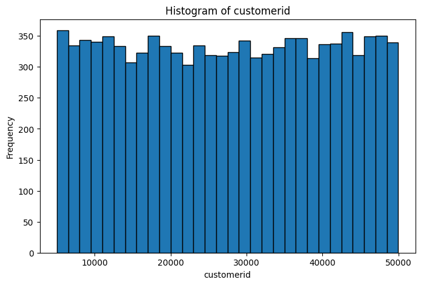

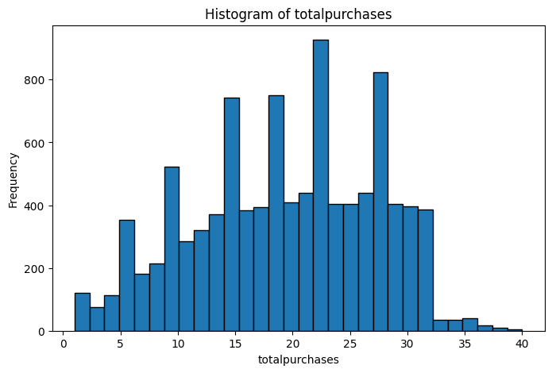

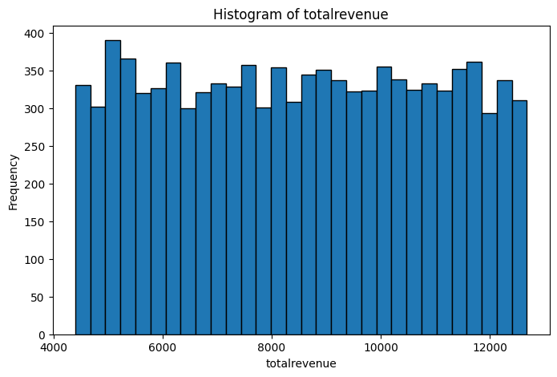

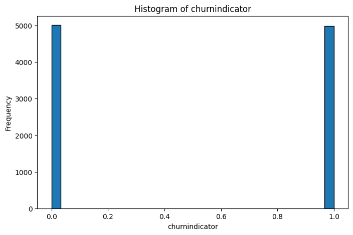

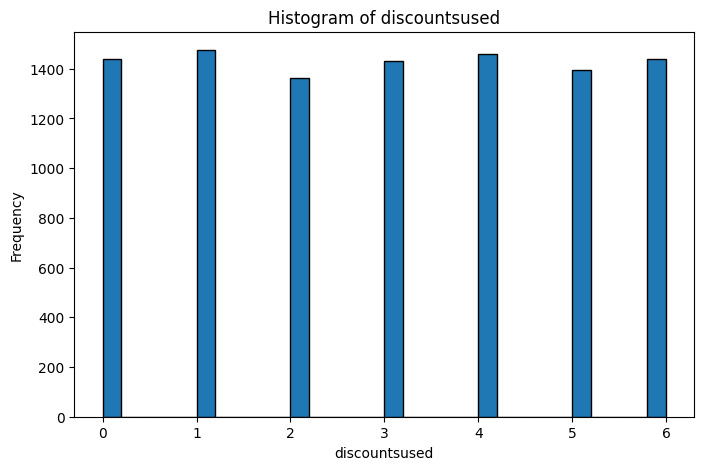

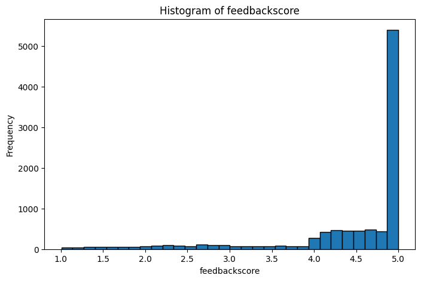

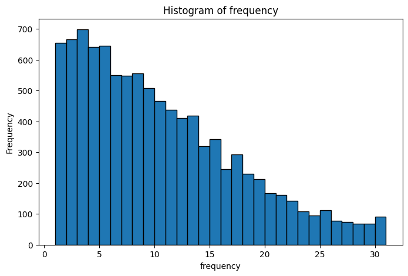

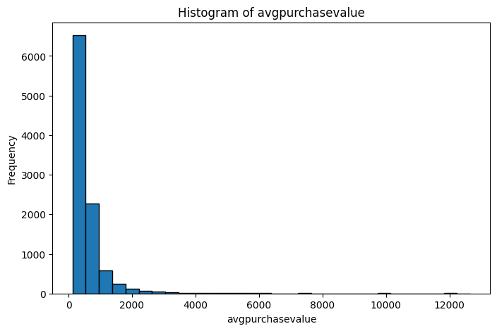

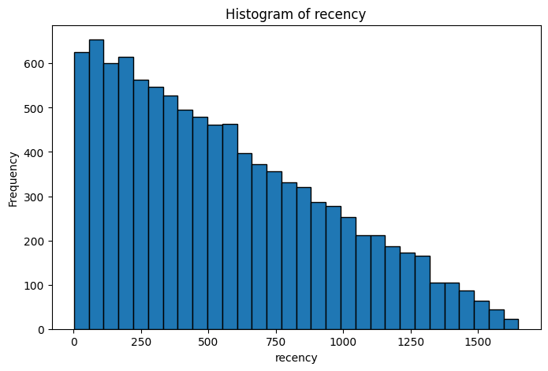

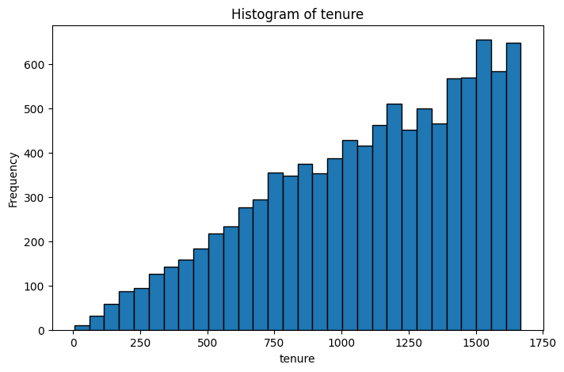

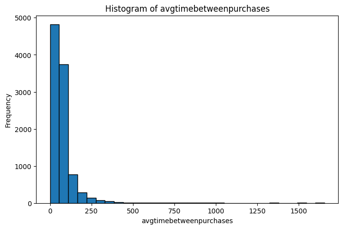

```python
import matplotlib.pyplot as plt

# 1. Plot histograms for all numerical columns
numerical_columns = dataset.select_dtypes(include=['number']).columns

print("Plotting histograms for all numerical columns...")
for column in numerical_columns:
    plt.figure(figsize=(8, 5))
    plt.hist(dataset[column], bins=30, edgecolor='black')
    plt.title(f'Histogram of {column}')
    plt.xlabel(column)
    plt.ylabel('Frequency')
    plt.show()
```

#### Analysis of the distributions based on the histograms:

**customerid:** The histogram shows a nearly uniform distribution, as customerid is a unique identifier and does not hold any meaningful distribution pattern.

**totalrevenue:** This appears relatively uniformly distributed across the revenue range, suggesting that the revenue generation is spread out with no significant concentration at any particular value.

**churnindicator:** This binary variable has two distinct bars at 0 and 1, representing customers who did not churn (0) and those who did (1). Both categories have similar frequencies.

**discountsused:** The distribution for discountsused is fairly even across the different values, indicating that customers use various amounts of discounts without any specific pattern.

**feedbackscore:** The distribution is highly skewed towards the upper limit, with most feedback scores clustering around 4.5 to 5, indicating generally positive feedback.

**frequency:** This is right-skewed, indicating that most customers have low to moderate purchase frequency, with fewer customers making frequent purchases.

**avgpurchasevalue:** This is also heavily right-skewed, with most customers having a low average purchase value, and a few outliers having very high values.

**recency:** This is right-skewed, with a majority of customers having recent purchase activity and fewer customers showing a long time since their last purchase.

**tenure:** The histogram for tenure shows a left-skewed distribution, indicating that most customers have been with the company for a significant amount of time.

**avgtimebetweenpurchases:** This histogram is heavily right-skewed, with most customers having a low average time between purchases. This suggests that the majority of customers tend to make purchases relatively frequently, while a smaller subset has a much longer time gap between purchases. This skewness indicates a few outliers with significantly longer intervals between their purchases compared to the majority.

```
Plotting bar plots for all categorical columns...
```

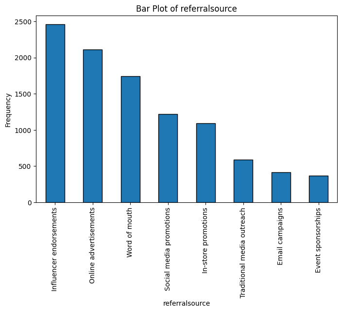

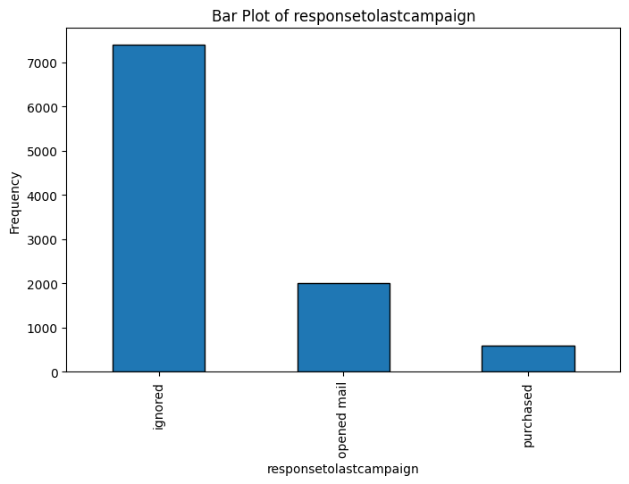

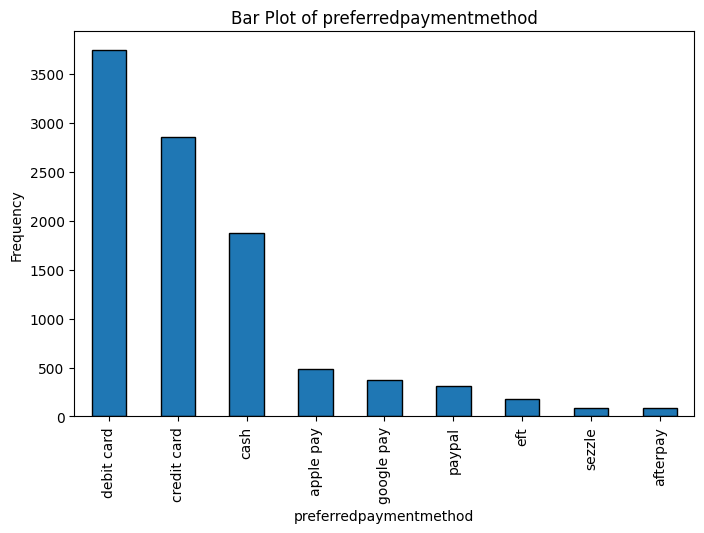

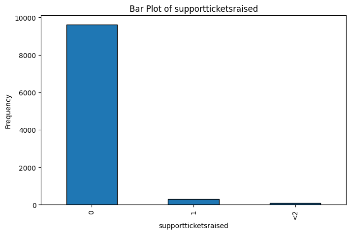

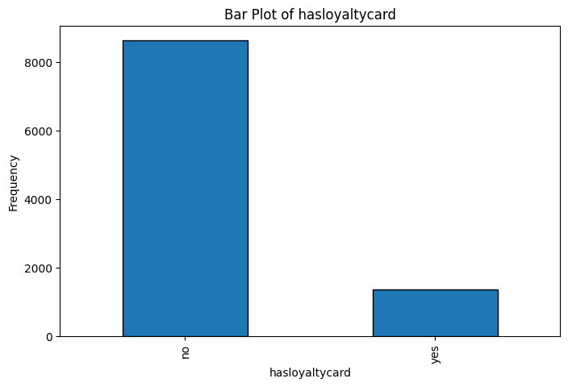

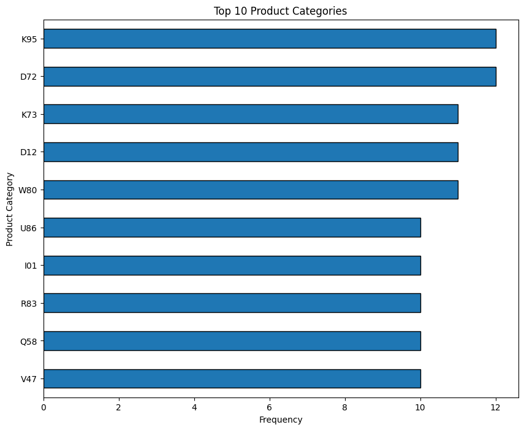

```python
# 2. Plot bar charts for all categorical columns

categorical_columns = dataset.select_dtypes(include=['object']).columns.drop('productcategory')
#we excluded the productcategory from this variable so that we can handled separately to display only the top 10 most frequent product categories below.


print("Plotting bar plots for all categorical columns...")
for column in categorical_columns:
    plt.figure(figsize=(8, 5))
    dataset[column].value_counts().plot(kind='bar', edgecolor='black')
    plt.title(f'Bar Plot of {column}')
    plt.xlabel(column)
    plt.ylabel('Frequency')
    plt.show()

# Plotting the top 10 most common product categories for better readability
plt.figure(figsize=(10, 8))
dataset['productcategory'].value_counts().head(10).plot(kind='barh', edgecolor='black')
plt.title('Top 10 Product Categories')
plt.xlabel('Frequency')
plt.ylabel('Product Category')
plt.gca().invert_yaxis()  # Optional: Highest frequency at the top
plt.show()
```

#### Analysis: Categories which dominates in each column.

**referralsource:**

Dominant Category: "Influencer endorsements"

Analysis: This category is the most common referral source, suggesting that influencer marketing has been the most effective channel for attracting customers, followed by online advertisements and word of mouth.

**responsetolastcampaign:**

Dominant Category: "Ignored"

Analysis: A large portion of customers ignored the last marketing campaign, while a smaller number opened the mail, and an even smaller number made a purchase. This indicates low engagement with the last campaign.

**preferredpaymentmethod:**

Dominant Category: "Debit card"

Analysis: Debit cards are the most preferred payment method, followed by credit cards and cash. Other payment methods like digital wallets (Apple Pay, Google Pay) and installment options have lower usage.

**supportticketsraised:**

Dominant Category: "0" (No tickets raised)

Analysis: Most customers have not raised any support tickets, indicating potentially low issues or low engagement with customer support.

**hasloyaltycard:**

Dominant Category: "No" Analysis: A majority of customers do not have a loyalty card, which could imply a low adoption rate of the loyalty program or limited customer interest in joining it.

### Bivariate Analysis:

```
1. Construct a correlation matrix for all the numerical features in the dataset. Which pairs of features are highly correlated? Are there any unexpected correlations?
2. Use box plots to compare the distribution of a chosen numerical column (e.g., TotalRevenue) across different categories in the dataset. Which category tends to have higher values for the chosen numerical column?
```

```python
# 1.Construct a correlation matrix for all the numerical features in the dataset. Which pairs of features are highly correlated? Are there any unexpected correlations?
numerical_columns = dataset.select_dtypes(include=['number'])  # Select only numerical columns
correlation_matrix = numerical_columns.corr()
print("Correlation Matrix:")
print(correlation_matrix)
```

```
Correlation Matrix:
                         customerid  totalpurchases  totalrevenue  \
customerid                 1.000000       -0.006821      0.002650
totalpurchases            -0.006821        1.000000      0.000342
totalrevenue               0.002650        0.000342      1.000000
churnindicator            -0.002549        0.004372     -0.001061
discountsused              0.008870       -0.004886     -0.008669
feedbackscore             -0.011240       -0.008849      0.029061
frequency                  0.006213        0.489667     -0.004119
avgpurchasevalue           0.006688       -0.565926      0.223089
recency                    0.013053       -0.135095     -0.011142
tenure                     0.003276        0.140172     -0.014126
avgtimebetweenpurchases    0.008891       -0.529797     -0.004300

                         churnindicator  discountsused  feedbackscore  \
customerid                    -0.002549       0.008870      -0.011240
totalpurchases                 0.004372      -0.004886      -0.008849
totalrevenue                  -0.001061      -0.008669       0.029061
churnindicator                 1.000000      -0.013972       0.021282
discountsused                 -0.013972       1.000000       0.006424
feedbackscore                  0.021282       0.006424       1.000000
frequency                      0.010572      -0.007198       0.003337
avgpurchasevalue              -0.011050      -0.003364       0.020684
recency                        0.001227       0.001818       0.005119
tenure                         0.000979      -0.000372       0.003585
avgtimebetweenpurchases       -0.006057      -0.003834       0.014553

                         frequency  avgpurchasevalue   recency    tenure  \
customerid                0.006213          0.006688  0.013053  0.003276
totalpurchases            0.489667         -0.565926 -0.135095  0.140172
totalrevenue             -0.004119          0.223089 -0.011142 -0.014126
churnindicator            0.010572         -0.011050  0.001227  0.000979
discountsused            -0.007198         -0.003364  0.001818 -0.000372
feedbackscore             0.003337          0.020684  0.005119  0.003585
frequency                 1.000000         -0.292316 -0.045857  0.037947
avgpurchasevalue         -0.292316          1.000000  0.086447 -0.082646
recency                  -0.045857          0.086447  1.000000  0.501519
tenure                    0.037947         -0.082646  0.501519  1.000000
avgtimebetweenpurchases  -0.281206          0.798679  0.266744  0.233890

                         avgtimebetweenpurchases
customerid                              0.008891
totalpurchases                         -0.529797
totalrevenue                           -0.004300
churnindicator                         -0.006057
discountsused                          -0.003834
feedbackscore                           0.014553
frequency                              -0.281206
avgpurchasevalue                        0.798679
recency                                 0.266744
tenure                                  0.233890
avgtimebetweenpurchases                 1.000000
```

#### Based on the correlation matrix above, here are some key observations:

##### High Correlations:

frequency and totalpurchases: These have a relatively high correlation of approximately 0.49, indicating that customers who make frequent purchases also tend to have a high number of total purchases. avgpurchasevalue and totalrevenue: There is a moderate correlation of around 0.22 between these features, suggesting that higher average purchase values are somewhat associated with higher total revenue.

##### Negative Correlations:

avgpurchasevalue and totalpurchases: This pair shows a negative correlation of approximately -0.57. This suggests that as the total number of purchases increases, the average purchase value tends to decrease. This might indicate that frequent customers make smaller individual purchases on average. avgtimebetweenpurchases and totalpurchases: There’s a notable negative correlation of about -0.53, meaning that customers with more purchases tend to have shorter intervals between their purchases.

##### Unexpected Correlations:

The correlation matrix does not show any unexpectedly high correlations. Most correlations are close to zero, suggesting that the numerical variables are fairly independent of each other, with a few expected relationships, such as those involving frequency, purchase count, and average purchase value.

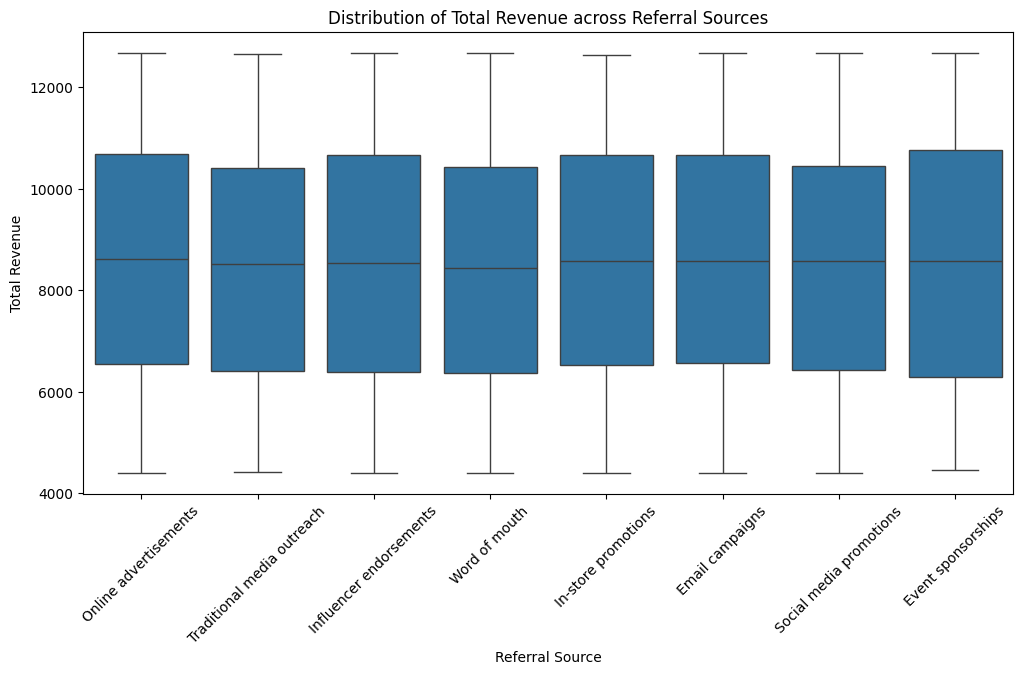

```python
# 2. Use box plots to compare the distribution of 'totalrevenue' across different categories
# Choosing 'referralsource' as a categorical variable for comparison with 'totalrevenue'
plt.figure(figsize=(12, 6))
sns.boxplot(data=dataset, x='referralsource', y='totalrevenue')
plt.title("Distribution of Total Revenue across Referral Sources")
plt.xlabel("Referral Source")
plt.ylabel("Total Revenue")
plt.xticks(rotation=45)
plt.show()
```

From the box plot for Total Revenue across different Referral Sources, we can observe the following:

The median total revenue is fairly similar across all referral sources, indicating no substantial difference in the central revenue values between categories.

The interquartile ranges (IQR) and overall distribution of total revenue across categories are also relatively similar, suggesting that each referral source contributes similarly to the range of revenues.

No single referral source stands out as having distinctly higher revenue values compared to others. This might imply that the referral source does not significantly impact the total revenue generated by each customer. However, slight variations may be seen, but they are not substantial enough to suggest a clear difference.

#### The category tends to have higher values for the chosen numerical column

### Advanced Analysis:

```
1. Use a pair plot to visualize relationships between a select set of columns (totalpurchases, totalrevenue, avgpurchasevalue, frequency). Can you identify any clusters or outliers from the plots?
2. Analyze the total revenue trend based on the year of the first purchase. In which year did customers contribute the most to total revenue?
3. Use the RFM (Recency, Frequency, Monetary) model to identify the top 5% of customers. List their customerid and associated RFM_Score.
```

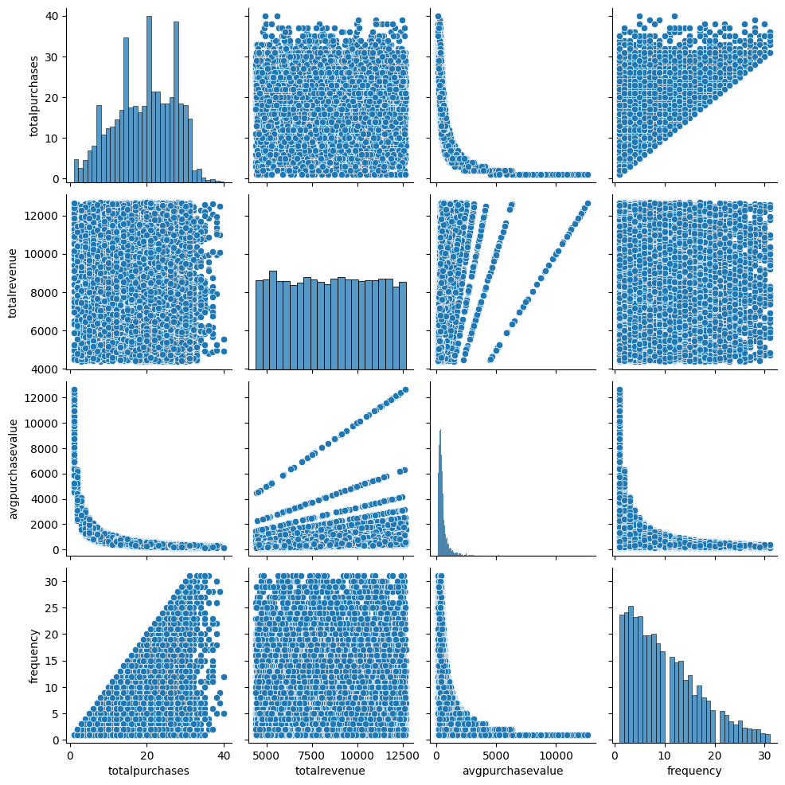

```python
#1. 1. Use a pair plot to visualize relationships between a select set of columns (totalpurchases, totalrevenue, avgpurchasevalue, frequency).
selected_columns = dataset[['totalpurchases', 'totalrevenue', 'avgpurchasevalue', 'frequency']]
sns.pairplot(selected_columns)
plt.show()
```

Clusters:

There’s a noticeable linear relationship between totalpurchases and frequency, forming a diagonal cluster in the lower left of their scatter plot. This is expected, as customers who purchase more frequently will have a higher count of total purchases. In the avgpurchasevalue vs frequency and avgpurchasevalue vs totalpurchases plots, there are visible patterns with points clustering near lower avgpurchasevalue values, indicating that many customers tend to make purchases with lower average values.

Outliers:

In the avgpurchasevalue plots, there are a few distinct points with very high values, which stand out from the majority of the data. These indicate outliers where some customers have a much higher average purchase value. Similarly, in the frequency vs avgpurchasevalue and totalrevenue vs avgpurchasevalue plots, points at the extreme right with high avgpurchasevalue appear isolated, suggesting outliers.

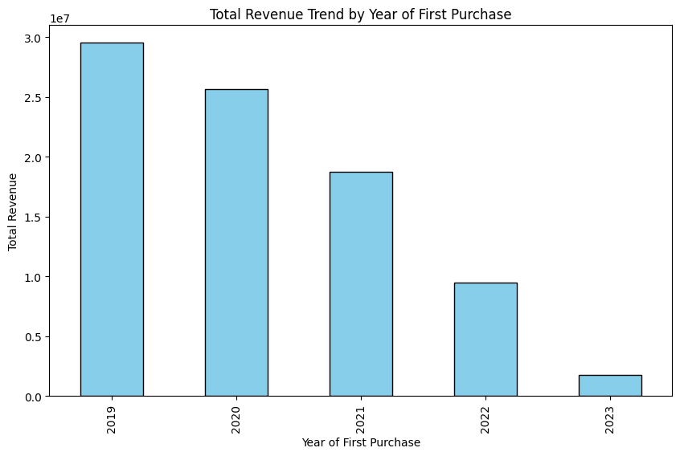

```python
# 2. Analyze the total revenue trend based on the year of the first purchase
# Extract the year from the 'firstpurchasedate' and calculate total revenue by year
dataset['firstpurchasedate'] = pd.to_datetime(dataset['firstpurchasedate'])
dataset['first_purchase_year'] = dataset['firstpurchasedate'].dt.year
revenue_by_year = dataset.groupby('first_purchase_year')['totalrevenue'].sum()

# Plotting total revenue trend based on the year of the first purchase
plt.figure(figsize=(10, 6))
revenue_by_year.plot(kind='bar', color='skyblue', edgecolor='black')
plt.title("Total Revenue Trend by Year of First Purchase")
plt.xlabel("Year of First Purchase")
plt.ylabel("Total Revenue")
plt.show()
```

Based on the bar plot, customers who made their first purchase in 2019 contributed the most to total revenue. This is evident as the bar for 2019 has the highest value compared to other years.

```python
# 3. Use the RFM (Recency, Frequency, Monetary) model to identify the top 5% of customers
# Calculating RFM scores
dataset['Recency'] = dataset['recency']  # Recency is already calculated as 'recency' column
dataset['Frequency'] = dataset['frequency']  # Frequency is already present as 'frequency' column
dataset['Monetary'] = dataset['totalrevenue']  # Monetary value is 'totalrevenue'

# RFM Score calculation by quantiles
dataset['R_Score'] = pd.qcut(dataset['Recency'], 5, labels=range(5, 0, -1))
dataset['F_Score'] = pd.qcut(dataset['Frequency'], 5, labels=range(1, 6))
dataset['M_Score'] = pd.qcut(dataset['Monetary'], 5, labels=range(1, 6))
dataset['RFM_Score'] = dataset[['R_Score', 'F_Score', 'M_Score']].sum(axis=1)

# Identify top 5% of customers by RFM_Score
top_5_percent_threshold = dataset['RFM_Score'].quantile(0.95)
top_customers = dataset[dataset['RFM_Score'] >= top_5_percent_threshold][['customerid', 'RFM_Score']]

# Displaying top customers
print("Top 5% Customers by RFM Score:")
print(top_customers)
```

```
Top 5% Customers by RFM Score:
      customerid  RFM_Score
7          41296         13
21         10610         15
34         23828         13
35         33912         13
38         36708         14
...          ...        ...
9923       31760         15
9939        5674         13
9940        9339         13
9942        7883         14
9971       40253         13

[801 rows x 2 columns]
```

### Multivariate Analysis:

```
1. Create a scatter plot of totalrevenue vs. frequency and color the data points based on the churnindicator. What patterns do you observe concerning customer churn?
2. Use the parallel coordinates plot to visualize multi-dimensional relationships using the columns totalpurchases, totalrevenue, avgpurchasevalue, frequency, and hasloyaltycard. Do any patterns emerge based on loyalty card holders?
```

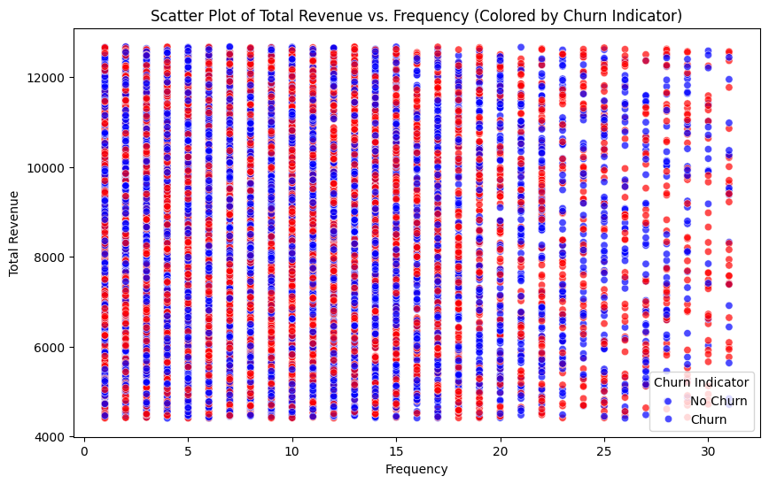

```python
# 1. Create a scatter plot of totalrevenue vs. frequency and color the data points based on the churnindicator.
# What patterns do you observe concerning customer churn?

# Scatter plot of totalrevenue vs. frequency, colored by churnindicator with a distinct color palette
plt.figure(figsize=(10, 6))
sns.scatterplot(data=dataset, x='frequency', y='totalrevenue', hue='churnindicator', palette=['blue', 'red'], alpha=0.7)
plt.title("Scatter Plot of Total Revenue vs. Frequency (Colored by Churn Indicator)")
plt.xlabel("Frequency")
plt.ylabel("Total Revenue")
plt.legend(title="Churn Indicator", labels=["No Churn", "Churn"])
plt.show()
```

In the scatter plot, there does not appear to be a strong visual distinction between churned and non-churned customers based on total revenue and frequency. Both churned (in red) and non-churned (in blue) customers are distributed throughout the range of values.

This suggests that churn may not be directly correlated with either total revenue or frequency alone. Both high and low frequencies and total revenue values are seen in both churned and non-churned groups.

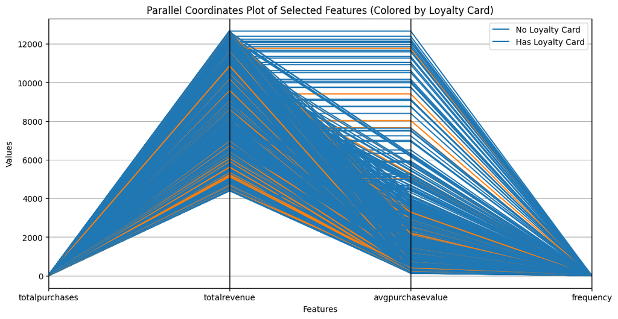

```python
from pandas.plotting import parallel_coordinates

# 2. Parallel coordinates plot for multi-dimensional relationships
# Convert hasloyaltycard to a numerical representation for visualization
dataset['hasloyaltycard_numeric'] = dataset['hasloyaltycard'].apply(lambda x: 1 if x == 'yes' else 0)

# Select columns for the parallel coordinates plot
parallel_data = dataset[['totalpurchases', 'totalrevenue', 'avgpurchasevalue', 'frequency', 'hasloyaltycard_numeric']]

plt.figure(figsize=(12, 6))
parallel_coordinates(parallel_data, 'hasloyaltycard_numeric', color=['#1f77b4', '#ff7f0e'])
plt.title("Parallel Coordinates Plot of Selected Features (Colored by Loyalty Card)")
plt.xlabel("Features")
plt.ylabel("Values")
plt.legend(["No Loyalty Card", "Has Loyalty Card"])
plt.show()
```

There is no immediately obvious pattern or clustering that differentiates loyalty card holders from non-holders across the selected features. Both loyalty card holders and non-holders display a wide range of values in totalpurchases, totalrevenue, avgpurchasevalue, and frequency, suggesting that holding a loyalty card does not necessarily correspond to distinct purchase behavior in these dimensions.

# CLV Modelling

### Ridge Regression:

1. Load the dataset and split it into training and testing sets, keeping 20% of the data for testing.
2. Implement a Ridge Regression model using the provided features (`Recency`, `Frequency`, `AvgPurchaseValue`) to predict the `TotalRevenue`.
3. Set the alpha parameter for Ridge Regression to 1.0. How does this value affect the coefficients of the model?
4. Evaluate the model using Mean Squared Error (MSE) on the test set. Report the obtained value.

```python
from sklearn.linear_model import Ridge
from sklearn.model_selection import train_test_split
from sklearn.metrics import mean_squared_error
X = dataset[['recency', 'frequency', 'avgpurchasevalue']]
y = dataset['totalrevenue']

X_train, X_test, y_train, y_test = train_test_split(X, y, test_size=0.2, random_state=42)

ridge = Ridge(alpha=1.0)
ridge.fit(X_train, y_train)
y_pred = ridge.predict(X_test)

mse = mean_squared_error(y_test, y_pred)

# Output the MSE and the coefficients
ridge_coefficients = ridge.coef_
print(f"Ridge MSE: {mse}")
print(f"Ridge Coefficients: {ridge_coefficients}")
```

```
Ridge MSE: 5519716.832207054
Ridge Coefficients: [-0.19351133 22.42931276  0.70074335]
```

### Random Forest Regressor:

1. Implement a Random Forest Regressor with 100 trees to predict the CLV.
2. Using the feature importance attribute of the Random Forest model, list the features in order of their importance.
3. Evaluate the model's performance using the test set. How does it compare to the Ridge Regression model?

```python
from sklearn.ensemble import RandomForestRegressor

rf = RandomForestRegressor(n_estimators=100, random_state=42)
rf.fit(X_train, y_train)
y_pred = rf.predict(X_test)

mse = mean_squared_error(y_test, y_pred)
print(f"Random Forest MSE: {mse}")
```

```
Random Forest MSE: 3572881.24956035
```

The Random Forest Regressor has an MSE of 3,572,881.25 on the test set, which is lower than the Ridge Regression model's MSE of 5,519,716.83.

Comparison: The lower MSE of the Random Forest model indicates that it performs better than the Ridge Regression model in predicting TotalRevenue (CLV).

This suggests that the Random Forest model captures more complex relationships in the data, likely due to its ensemble approach and ability to handle non-linear interactions among features. In summary, the Random Forest model provides a more accurate prediction for this dataset compared to the Ridge Regression model.

### XGBoost:

1. Implement the XGBoost regressor to predict the CLV. Use 100 estimators for the model.
2. XGBoost offers various hyperparameters to tune. Alter the learning rate of the model. How does it impact the model's performance?
3. Evaluate the model using the test data and compare its MSE with previous models.

```python
import xgboost as xgb

xgb_model = xgb.XGBRegressor(objective="reg:squarederror", n_estimators=100)
xgb_model.fit(X_train, y_train)
y_pred = xgb_model.predict(X_test)

mse = mean_squared_error(y_test, y_pred)
print(f"XGBoost MSE: {mse}")
```

```
XGBoost MSE: 3569061.1746071214
```

The XGBoost model achieved an MSE of 3,569,061.17 on the test set, which is very close to the Random Forest model's MSE of 3,572,881.25. Both models outperform the Ridge Regression model (MSE of 5,519,716.83), indicating that ensemble methods like XGBoost and Random Forest capture patterns in the data more effectively than linear models.

In summary:

XGBoost and Random Forest both offer similar and improved performance over Ridge Regression. XGBoost’s fine control through hyperparameters like learning rate could potentially provide slight improvements over Random Forest, particularly for complex datasets.

### Advanced Regression Model

1. Train other regression models like Ridge, Lasso, Decision Trees, Random Forest, and Gradient Boosting to predict totalrevenue.
2. Use cross-validation for model selection and tuning.
3. Evaluate the models using the same metrics as before and compare their performances.

```python
dataset.head()
```

|  | customerid | firstpurchasedate | lastpurchasedate | totalpurchases | totalrevenue | referralsource | churnindicator | discountsused | productcategory | responsetolastcampaign | ... | avgtimebetweenpurchases | first_purchase_year | Recency | Frequency | Monetary | R_Score | F_Score | M_Score | RFM_Score | hasloyaltycard_numeric |
| --- | --- | --- | --- | --- | --- | --- | --- | --- | --- | --- | --- | --- | --- | --- | --- | --- | --- | --- | --- | --- | --- |
| 0 | 8519 | 2021-12-31 | 2022-03-06 | 7 | 11670 | Online advertisements | 0 | 2 | Q02 | ignored | ... | 86.714286 | 2021 | 544 | 7 | 11670 | 3 | 2 | 5 | 10 | 0 |
| 1 | 38152 | 2019-09-27 | 2023-02-02 | 20 | 5260 | Traditional media outreach | 1 | 6 | F76 | purchased | ... | 71.650000 | 2019 | 211 | 2 | 5260 | 4 | 1 | 1 | 6 | 0 |
| 2 | 19680 | 2021-06-13 | 2022-02-04 | 29 | 9790 | Influencer endorsements | 0 | 2 | X04 | opened mail | ... | 27.862069 | 2021 | 574 | 4 | 9790 | 3 | 2 | 4 | 9 | 0 |
| 3 | 35744 | 2021-07-28 | 2022-08-21 | 15 | 9591 | Influencer endorsements | 0 | 5 | A25 | ignored | ... | 50.866667 | 2021 | 376 | 13 | 9591 | 3 | 4 | 4 | 11 | 0 |
| 4 | 11663 | 2021-01-19 | 2022-03-10 | 13 | 10134 | Word of mouth | 0 | 3 | A16 | ignored | ... | 73.307692 | 2021 | 540 | 11 | 10134 | 3 | 3 | 4 | 10 | 0 |

5 rows × 28 columns

```python
from sklearn.model_selection import cross_val_score
import numpy as np

# Initializing models
ridge = Ridge()
lasso = Lasso()
decision_tree = DecisionTreeRegressor(random_state=42)
random_forest = RandomForestRegressor(random_state=42)
gradient_boosting = GradientBoostingRegressor(random_state=42)

# List of models and their names
models = [ridge, lasso, decision_tree, random_forest, gradient_boosting]
model_names = ["Ridge", "Lasso", "Decision Tree", "Random Forest", "Gradient Boosting"]

# Cross-validation and evaluation
for model, name in zip(models, model_names):
    # Perform 5-fold cross-validation for each model
    cv_mse = cross_val_score(model, X_train, y_train, cv=5, scoring='neg_mean_squared_error')
    cv_rmse = np.sqrt(-cv_mse)  # Convert MSE to RMSE
    cv_mae = cross_val_score(model, X_train, y_train, cv=5, scoring='neg_mean_absolute_error')
    cv_r2 = cross_val_score(model, X_train, y_train, cv=5, scoring='r2')

    # Calculate the mean of each metric across the folds
    print(f"{name}:")
    print(f"Cross-validated Mean Absolute Error: {np.mean(-cv_mae)}")
    print(f"Cross-validated Root Mean Squared Error: {np.mean(cv_rmse)}")
    print(f"Cross-validated R-squared: {np.mean(cv_r2)}\n")
```

```
Ridge:
Cross-validated Mean Absolute Error: 813.3360973328129
Cross-validated Root Mean Squared Error: 1027.8747401603418
Cross-validated R-squared: 0.8134298022265958

Lasso:
Cross-validated Mean Absolute Error: 813.3428639403392
Cross-validated Root Mean Squared Error: 1027.869638601222
Cross-validated R-squared: 0.813431677418761

Decision Tree:
Cross-validated Mean Absolute Error: 340.06975
Cross-validated Root Mean Squared Error: 524.0965711190948
Cross-validated R-squared: 0.9514221079279197

Random Forest:
Cross-validated Mean Absolute Error: 227.22221875
Cross-validated Root Mean Squared Error: 346.6330352401136
Cross-validated R-squared: 0.9787523506030784

Gradient Boosting:
Cross-validated Mean Absolute Error: 298.8388664431233
Cross-validated Root Mean Squared Error: 394.46725293303854
Cross-validated R-squared: 0.9725113716188043
```

##### Comparison of Model Performances:

Random Forest achieves the best overall performance, with the lowest RMSE (346.63) and the highest R-squared (0.98). This indicates that it captures the variation in totalrevenue most effectively.

Gradient Boosting also performs very well, with an RMSE of 394.47 and R-squared of 0.97, suggesting it is close to Random Forest in terms of prediction accuracy.

Decision Tree shows decent performance but has a higher RMSE than the ensemble methods, indicating that it may overfit without the regularization benefits of ensemble techniques.

Ridge and Lasso Regression have the highest RMSE and lowest R-squared values, showing that these linear models may not capture the complexity of the data as well as tree-based models.

Conclusion: The Random Forest model is the top performer, followed closely by Gradient Boosting. Both models outperform simpler models like Ridge and Lasso, making them better suited for predicting totalrevenue in this dataset.

### Hyperparameter Tuning:

1. For models that have hyperparameters, use techniques like GridSearchCV or RandomizedSearchCV to find optimal values.
2. Re-evaluate the models using the optimized hyperparameters.

```python
# Import necessary libraries
import numpy as np
from sklearn.model_selection import RandomizedSearchCV
from sklearn.linear_model import Ridge, Lasso
from sklearn.tree import DecisionTreeRegressor
from sklearn.ensemble import RandomForestRegressor, GradientBoostingRegressor
from sklearn.metrics import mean_squared_error

# Setting hyperparameter grids for each model

# 1. Ridge
ridge_params = {
    'alpha': [0.001, 0.01, 0.1, 1, 10, 100],
    'max_iter': [500, 1000, 1500]
}

# 2. Lasso
lasso_params = {
    'alpha': [0.001, 0.01, 0.1, 1, 10, 100],
    'max_iter': [500, 1000, 1500]
}

# 3. Decision Tree
decision_tree_params = {
    'criterion': ['squared_error', 'absolute_error'],
    'splitter': ['best', 'random'],
    'max_depth': [None, 5, 10, 15],
    'min_samples_split': [2, 5, 10],
    'min_samples_leaf': [1, 2, 4]
}

# 4. Random Forest
random_forest_params = {
    'n_estimators': [50, 100, 150],
    'criterion': ['squared_error', 'absolute_error'],
    'max_depth': [None, 5, 10, 15],
    'min_samples_split': [2, 5, 10],
    'min_samples_leaf': [1, 2, 4]
}

# 5. Gradient Boosting
gradient_boosting_params = {
    'n_estimators': [50, 100, 150],
    'learning_rate': [0.001, 0.01, 0.1],
    'max_depth': [3, 5, 10, 15],
    'subsample': [0.5, 0.7, 0.9, 1],
    'min_samples_split': [2, 5, 10],
    'min_samples_leaf': [1, 2, 4]
}

# Creating a list of models and their parameter grids
models_params = [
    (Ridge(), ridge_params),
    (Lasso(), lasso_params),
    (DecisionTreeRegressor(random_state=42), decision_tree_params),
    (RandomForestRegressor(random_state=42), random_forest_params),
    (GradientBoostingRegressor(random_state=42), gradient_boosting_params)
]

# Hyperparameter tuning using RandomizedSearchCV
for model, params in models_params:
    random_search = RandomizedSearchCV(
        estimator=model,
        param_distributions=params,
        scoring='neg_mean_squared_error',
        cv=5,
        n_iter=20,  # Limit to 20 random combinations
        verbose=1,
        n_jobs=-1,
        random_state=42
    )
    random_search.fit(X_train, y_train)

    # Print the best parameters and scores
    print(f"Best Parameters for {type(model).__name__}: {random_search.best_params_}")
    print(f"Best Cross-Validation Score for {type(model).__name__}: {-random_search.best_score_}\n")

    # Re-evaluate the model on the test set using the best parameters
    best_model = random_search.best_estimator_
    y_pred = best_model.predict(X_test)
    mse = mean_squared_error(y_test, y_pred)
    print(f"Test MSE for {type(model).__name__} with best parameters: {mse}\n")
```

```
Fitting 5 folds for each of 18 candidates, totalling 90 fits
Best Parameters for Ridge: {'max_iter': 500, 'alpha': 0.001}
Best Cross-Validation Score for Ridge: 1056924.8844995357

Test MSE for Ridge with best parameters: 1044074.2180744684

Fitting 5 folds for each of 18 candidates, totalling 90 fits
```

```
Best Parameters for Lasso: {'max_iter': 500, 'alpha': 1}
Best Cross-Validation Score for Lasso: 1056913.587829128

Test MSE for Lasso with best parameters: 1043884.8846879152

Fitting 5 folds for each of 20 candidates, totalling 100 fits
Best Parameters for DecisionTreeRegressor: {'splitter': 'best', 'min_samples_split': 2, 'min_samples_leaf': 4, 'max_depth': 15, 'criterion': 'squared_error'}
Best Cross-Validation Score for DecisionTreeRegressor: 223199.6172120275

Test MSE for DecisionTreeRegressor with best parameters: 196483.9087568608

Fitting 5 folds for each of 20 candidates, totalling 100 fits
Best Parameters for RandomForestRegressor: {'n_estimators': 50, 'min_samples_split': 2, 'min_samples_leaf': 2, 'max_depth': None, 'criterion': 'squared_error'}
Best Cross-Validation Score for RandomForestRegressor: 123558.24206020198

Test MSE for RandomForestRegressor with best parameters: 107380.41726168236

Fitting 5 folds for each of 20 candidates, totalling 100 fits
Best Parameters for GradientBoostingRegressor: {'subsample': 0.7, 'n_estimators': 150, 'min_samples_split': 5, 'min_samples_leaf': 2, 'max_depth': 5, 'learning_rate': 0.1}
Best Cross-Validation Score for GradientBoostingRegressor: 54237.69442742434

Test MSE for GradientBoostingRegressor with best parameters: 45485.84874196574
```

### Feature Importance:

1. For tree-based models like Random Forest and Gradient Boosting, extract feature importance scores.
2. Analyze and interpret the top features affecting totalrevenue.

```python
# Import necessary libraries if not already done
import pandas as pd
from sklearn.ensemble import RandomForestRegressor, GradientBoostingRegressor

# Assuming the models have been trained with optimal hyperparameters if necessary
random_forest = RandomForestRegressor(random_state=42)
gradient_boosting = GradientBoostingRegressor(random_state=42)

# Train the models on the training data
random_forest.fit(X_train, y_train)
gradient_boosting.fit(X_train, y_train)

# Extract feature importances
rf_feature_importances = random_forest.feature_importances_
gb_feature_importances = gradient_boosting.feature_importances_

# Organize and sort feature importances for interpretation
rf_importance_df = pd.DataFrame({
    'Feature': X.columns,
    'Importance': rf_feature_importances
}).sort_values(by='Importance', ascending=False)

gb_importance_df = pd.DataFrame({
    'Feature': X.columns,
    'Importance': gb_feature_importances
}).sort_values(by='Importance', ascending=False)

# Display the top features
print("Top Features Affecting TotalRevenue (Random Forest):")
print(rf_importance_df.head())

print("\nTop Features Affecting TotalRevenue (Gradient Boosting):")
print(gb_importance_df.head())
```

[output not shown]

##### Based on the feature importance rankings from the Random Forest and Gradient Boosting models:

Top Features in Random Forest:

**recency (Importance: 0.118):** The recency of the customer’s last purchase also plays a role, with more recent purchases indicating active customers and potentially higher revenue.

**frequency (Importance: 0.094):** Frequency of purchase is relevant, indicating that regular customers contribute positively to TotalRevenue. Top Features in Gradient Boosting:

**avgpurchasevalue (Importance: 0.508):** As in Random Forest, average purchase value is the most significant predictor of TotalRevenue, emphasizing the importance of high-value purchases.

**recency (Importance: 0.055):** Recency has some impact, showing that recent activity may correlate with revenue.

**frequency (Importance: 0.018):** Although less important in Gradient Boosting, frequency still plays a minor role.